# How Instagram Recommends Content Throughout the Day

## Part 1: Happiness?

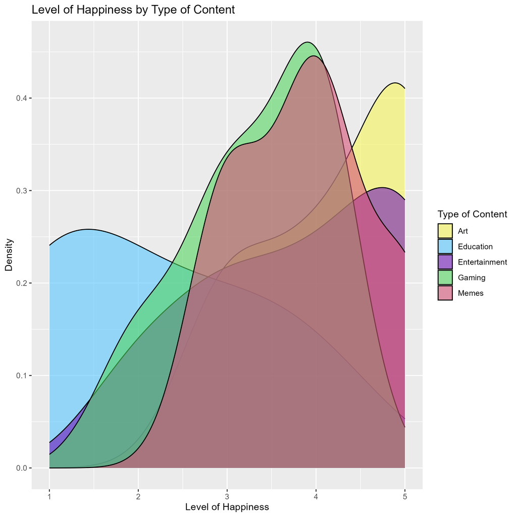

To tell my visual story, I thought it would be best to start with my perspective on the different types of content recommended in the first place. The level of happiness in my data is representative of the general opinion of one’s content feed. As shown in the graph above, the level of happiness is not fully consistent across any one type of content, but some still clearly average more happiness than others. Notably, ‘Art’ seems to get the most happiness, with ‘Education’ getting the least.

Overall, the data shows that Instagram content doesn’t always hit the mark, even when showing you types of content that you more often enjoy, **but** it also says something that it can determine what you do enjoy.

## Part 2: How Frequent?

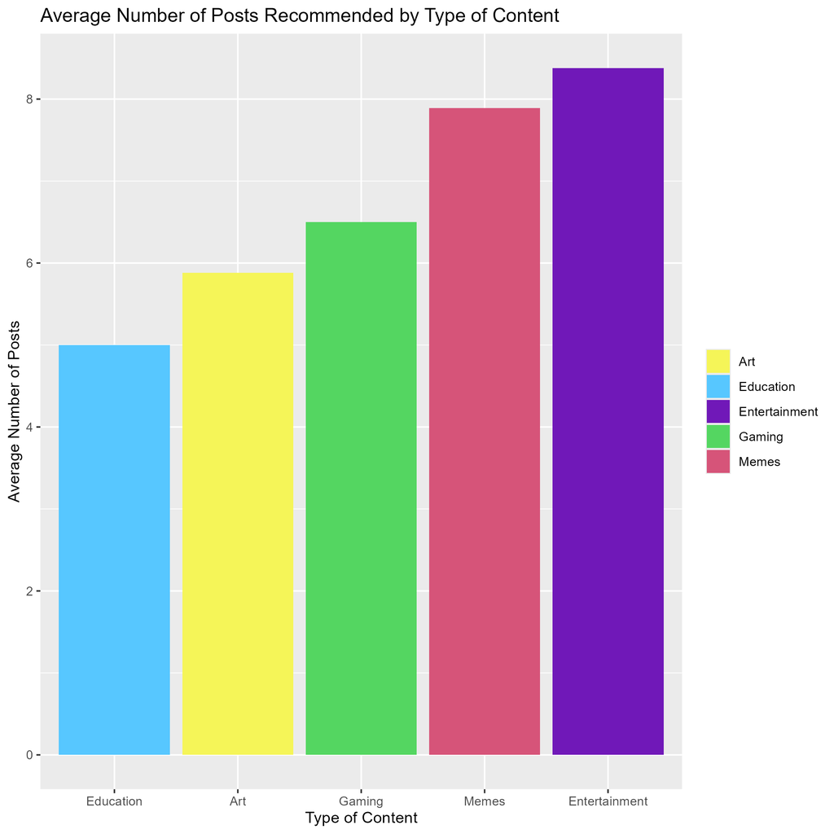

Next, after determining the general level of satisfaction with each type of content, I wanted to visualise how these types of content stacked up against each other by sheer numbers. How *often* were they showing up? When they were the most prominent category at a particular time, how many posts were of this type of content? This visualisation was useful to show how frequently pushed certain types of content were. There is a clear hierarchy here, showing how ‘Entertainment’ posts are most common. It also helps cement the findings of ‘Education’ posts being least common as they are associated with the lowest level of happiness (ironically).

Overall, this data helps further back the story being pushed here: that Instagram has a grasp on what kinds of content it should be trying to recommend, giving some more frequency than others! The only thing left to check now is how all of these findings relate to…

## Part 3: …Time of Day?

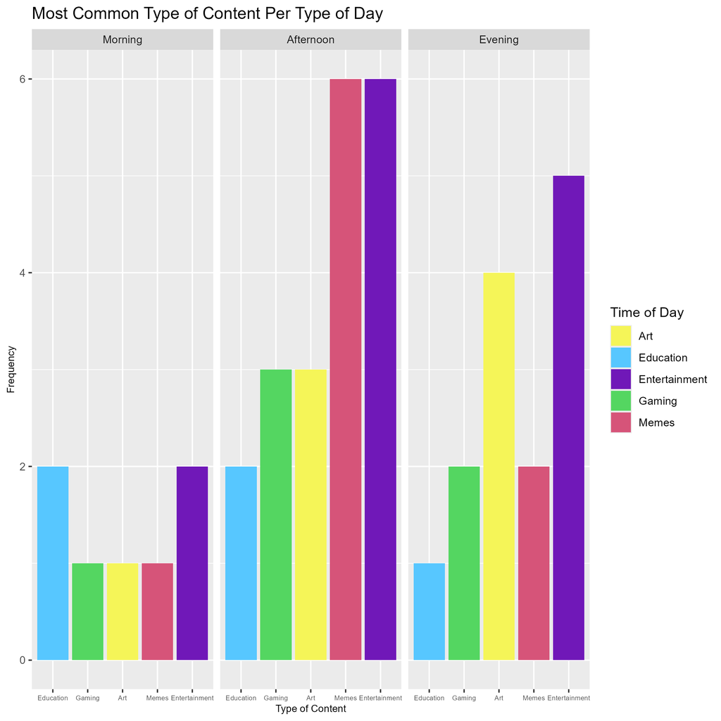

The individual logs of data have been assigned different times of day depending on when they were logged: Morning (6am-12pm), Afternoon (12pm-5pm) and Evening (5pm-10pm). Using this, the graph above depicts the frequency of types of content per time-period.

Combining this with the info from the previous two parts allows us to paint a picture of how Instagram might go about its content recommendations. In the morning, there is quite a uniform balance: ‘Education’ and ‘Entertainment’ posts are pushed more frequently, with other types of content also getting their fair share of recommendations. With this, it might be possible to infer that Instagram provides more ‘thoughtful’ content to start the day: educational posts or posts about entertainment, rather than things like memes or gaming content. With the happiness levels given in part 1, we can see that the morning is the least ‘successful’ time period.

In the afternoon, there is much more engagement with Instagram and much more of a clear bias toward certain types of content. The afternoon is the time Instagram thinks to go for more brazenly ‘fun’ content, with tons of memes and entertainment-related posts. Of course, it still tries to sprinkle in some variation, but definitely less than in the morning. As the afternoon is typically the time when someone is most ‘active’, I think Instagram is trying to ‘lighten up’ here with more entertaining content, sure to give more happiness!

Lastly, in the evenings, there is a spike up in the amount of art content recommended, while the amount of memes faces a sharp decrease. Here, as people wind down for the day, Instagram tends to recommend ‘lighter’ content, focusing more on things like art than on memes or gaming. Interestingly, the algorithm seems to start pushing more content that you might *not* always like mixed in more frequently with what you *will* like.

Altogether, the visualisations tell a pretty cohesive ‘story’ following the habits Instagram follows in recommendation throughout the day: how it keeps track of one’s preferred type of content and how it will push variations throughout the day.